# Análisis Exploratorio de Datos (EDA)

## Predicción espacio-temporal de la intensidad de tráfico por evento en Barcelona

Este cuaderno realiza el análisis exploratorio de todos los conjuntos de datos disponibles para el proyecto:

| Dataset | Descripción |
| --- | --- |
| **Itineraris** | Intensidad de tráfico por tramo (2021–2024, mensual) |
| **Trams** | Definición geográfica de los tramos de la red viaria |
| **Trams-Itineraris** | Relación tramo ↔ itinerario |
| **Festivales / Fiestas** | Calendario de fiestas y festivales de la ciudad (2021–2024) |
| **Agenda cultural** | Eventos culturales con fecha, ubicación y coordenadas |
| **Agenda de actividades** | Actividades y eventos generales |
| **Meteorología** | Datos meteorológicos de estaciones de Barcelona (2021–2024) |
| **Accidentes** | Accidentes de tráfico registrados (2021–2024) |

## 0. Configuración e imports

```python
# Ruta base local
from pathlib import Path
BASE = Path('../dataset')
```

```python
# Se realiza el montaje de la unidad de Google Drive para acceder a los ficheros
#from google.colab import drive

#drive.mount('/drive')

#BASE = Path('/drive/My Drive/Colab Notebooks/TM/dataset')
```

```python
import os
import glob
import warnings

import numpy as np
import pandas as pd
import matplotlib.pyplot as plt
import matplotlib.dates as mdates
import seaborn as sns

warnings.filterwarnings('ignore')
pd.set_option('display.max_columns', 50)
pd.set_option('display.float_format', '{:.4f}'.format)

sns.set_theme(style='whitegrid', palette='muted', font_scale=1.1)
plt.rcParams['figure.figsize'] = (12, 5)

# Rutas base
PATH_ITINERARIS = BASE / 'Itineraris'
PATH_TRAMS      = BASE / 'Trams'
PATH_TRAM_ITIS  = BASE / 'Trams - Itineraris'
PATH_FESTIVALES = BASE / 'Festivales'
PATH_FIESTAS    = BASE / 'Fiestas'
PATH_AGENDA_C   = BASE / 'Agenda cultural'
PATH_AGENDA_A   = BASE / 'Agenda de eventos y actividades'
PATH_METEO      = BASE / 'Meteorología'
PATH_ACCIDENTES = BASE / 'Accidentes'

print('Rutas configuradas correctamente.')
```

```
Rutas configuradas correctamente.
```

## 1. Datos de tráfico — Itineraris

Estos ficheros contienen la intensidad de tráfico medida cada ~5 minutos para cada tramo de la red viaria principal de Barcelona.

### 1.1 Carga de datos

```python
# Carga de un fichero de muestra para inspección inicial
sample_file = PATH_ITINERARIS / '2024_01_Gener_ITINERARIS_ITINERARIS.csv'
df_sample = pd.read_csv(sample_file)

print(f'Dimensiones: {df_sample.shape}')
print(f'\nColumnas: {df_sample.columns.tolist()}')
print(f'\nPrimeras filas:')
df_sample.head()
```

```
Dimensiones: (344604, 8)

Columnas: ['idTram', 'infoDisponible', 'data', 'tempsActual', 'tempsPrevist', 'tempsRecorregutFutur', 'factorReferenciaActual', 'tendencia']

Primeras filas:
```

|  | idTram | infoDisponible | data | tempsActual | tempsPrevist | tempsRecorregutFutur | factorReferenciaActual | tendencia |
| --- | --- | --- | --- | --- | --- | --- | --- | --- |
| 0 | 1 | 1 | 20240101000552 | 0 | 0 | -1 | -1 | -1 |
| 1 | 2 | 1 | 20240101000552 | 0 | 0 | -1 | -1 | -1 |
| 2 | 3 | 1 | 20240101000552 | 304 | 304 | 1 | 1 | 1 |
| 3 | 4 | 1 | 20240101000552 | 324 | 324 | 1 | 1 | 1 |
| 4 | 5 | 1 | 20240101000552 | 174 | 174 | 1 | 1 | 1 |

```python
# Descripción del significado de cada columna
print("""
Descripción de columnas:
  idTram                : Identificador del tramo de la red viaria
  infoDisponible        : 1 si hay datos disponibles, 0 si no
  data                  : Timestamp en formato YYYYMMDDHHMMSS
  tempsActual           : Tiempo actual de recorrido del itinerario (segundos)
  tempsPrevist          : Tiempo previsto de recorrido (segundos)
  tempsRecorregutFutur  : Tiempo de recorrido futuro estimado (segundos)
  factorReferenciaActual: Factor de tráfico actual respecto al de referencia
  tendencia             : Tendencia de la congestión (-1: mejora, 0: estable, 1: empeora)
""")

df_sample.dtypes
```

```
Descripción de columnas:
  idTram                : Identificador del tramo de la red viaria
  infoDisponible        : 1 si hay datos disponibles, 0 si no
  data                  : Timestamp en formato YYYYMMDDHHMMSS
  tempsActual           : Tiempo actual de recorrido del itinerario (segundos)
  tempsPrevist          : Tiempo previsto de recorrido (segundos)
  tempsRecorregutFutur  : Tiempo de recorrido futuro estimado (segundos)
  factorReferenciaActual: Factor de tráfico actual respecto al de referencia
  tendencia             : Tendencia de la congestión (-1: mejora, 0: estable, 1: empeora)
```

```
idTram                    int64
infoDisponible            int64
data                      int64
tempsActual               int64
tempsPrevist              int64
tempsRecorregutFutur      int64
factorReferenciaActual    int64
tendencia                 int64
dtype: object
```

```python
def cargar_itineraris(años=None, meses=None):
    """
    Carga y concatena los ficheros de tráfico (Itineraris).

    Parámetros:
        años  : lista de años a cargar (ej. [2022, 2023, 2024]). None = todos.
        meses : lista de meses a cargar (1-12). None = todos.
    """
    archivos = sorted(PATH_ITINERARIS.glob('*_ITINERARIS_ITINERARIS.csv'))

    dfs = []
    for f in archivos:
        nombre = f.stem  # ej. '2024_01_Gener_ITINERARIS_ITINERARIS'
        partes = nombre.split('_')
        año = int(partes[0])
        mes = int(partes[1])

        if años and año not in años:
            continue
        if meses and mes not in meses:
            continue

        df = pd.read_csv(f, low_memory=False)
        df['_año'] = año
        df['_mes'] = mes
        dfs.append(df)

    if not dfs:
        return pd.DataFrame()

    resultado = pd.concat(dfs, ignore_index=True)

    # Parsear timestamp
    resultado['timestamp'] = pd.to_datetime(
        resultado['data'].astype(str), format='%Y%m%d%H%M%S', errors='coerce'
    )
    resultado = resultado.drop(columns=['data'])

    # Reemplazar valores -1 (sin datos) por NaN en columnas numéricas
    for col in ['tempsActual', 'tempsPrevist', 'tempsRecorregutFutur', 'factorReferenciaActual', 'tendencia']:
        resultado[col] = resultado[col].replace(-1, np.nan)

    return resultado

print('Función cargar_itineraris() definida.')
```

```
Función cargar_itineraris() definida.
```

```python
# Carga de años 2021-2024 para el análisis principal
print('Cargando datos de tráfico 2021-2024...')
df_trafico = cargar_itineraris(años=[2021, 2022, 2023, 2024])

print(f'Total de registros: {len(df_trafico):,}')
print(f'Tramos únicos: {df_trafico["idTram"].nunique()}')
print(f'Rango temporal: {df_trafico["timestamp"].min()} → {df_trafico["timestamp"].max()}')
df_trafico.head()
```

```
Cargando datos de tráfico 2021-2024...
Total de registros: 21,386,724
Tramos únicos: 157
Rango temporal: 2021-01-01 00:05:52 → 2024-12-31 23:50:54
```

|  | idTram | infoDisponible | tempsActual | tempsPrevist | tempsRecorregutFutur | factorReferenciaActual | tendencia | _año | _mes | timestamp |
| --- | --- | --- | --- | --- | --- | --- | --- | --- | --- | --- |
| 0 | 1 | 1 | 300 | 300 | 1 | 1 | 1 | 2021 | 1 | 2021-01-01 00:05:52 |
| 1 | 2 | 1 | 255 | 255 | 1 | 1 | 1 | 2021 | 1 | 2021-01-01 00:05:52 |
| 2 | 3 | 1 | 304 | 305 | 1 | 1 | 1 | 2021 | 1 | 2021-01-01 00:05:52 |
| 3 | 4 | 1 | 324 | 324 | 1 | 1 | 1 | 2021 | 1 | 2021-01-01 00:05:52 |
| 4 | 5 | 1 | 175 | 175 | 1 | 1 | 1 | 2021 | 1 | 2021-01-01 00:05:52 |

### Carga de tráfico (2021-2024)

La carga de datos de tráfico revela un volumen masivo de información, con más de 21 millones de registros que proporcionan la granularidad necesaria para capturar patrones horarios y diarios complejos. Esta densidad de datos es fundamental para entender el comportamiento de la red viaria en Barcelona a lo largo del tiempo.

Desde una perspectiva espacial, el monitoreo recurrente de 157 tramos muestra una consistencia notable. Esta estabilidad en la red de sensores facilitará significativamente el mapeo geográfico y la integración con otras fuentes de datos espaciales en las etapas posteriores del proyecto.

### 1.2 Calidad de datos

```python
print('=== Valores nulos (%) ===')
nulos = df_trafico.isnull().mean() * 100
print(nulos[nulos > 0].sort_values(ascending=False).to_string())

print('\n=== Registros con infoDisponible=0 ===')
sin_info = (df_trafico['infoDisponible'] == 0).sum()
print(f'{sin_info:,} ({sin_info/len(df_trafico)*100:.1f}%)')

print('\n=== Estadísticas descriptivas ===')
df_trafico[['tempsActual', 'tempsPrevist', 'factorReferenciaActual', 'tendencia']].describe()
```

```
=== Valores nulos (%) ===
factorReferenciaActual   30.8805
tendencia                30.8805
tempsRecorregutFutur     30.1683
timestamp                 0.0000

=== Registros con infoDisponible=0 ===
5,405,013 (25.3%)

=== Estadísticas descriptivas ===
```

|  | tempsActual | tempsPrevist | factorReferenciaActual | tendencia |
| --- | --- | --- | --- | --- |
| count | 21386724 | 21386724 | 14782402 | 14782402 |
| unique | 2695 | 2504 | 8 | 8 |
| top | 0 | 0 | 1 | 1 |
| freq | 6452012 | 6604319 | 13894515 | 14173299 |

### Calidad de los datos

El análisis de valores nulos revela que aproximadamente el 30% de los registros carecen de datos en columnas críticas como factorReferenciaActual, tendencia y tempsRecorregutFutur. Esta ausencia de información es significativa y coincide estrechamente con el volumen de registros que tienen el indicador infoDisponible en 0, lo que representa el 25.3% del total (más de 5.4 millones de filas). Esta correlación sugiere que cuando el sistema marca la información como no disponible, los campos de métricas de tráfico no se calculan o no se reportan.

En cuanto a las estadísticas descriptivas, se observa una gran cantidad de valores en 0 para tempsActual y tempsPrevist. Esto podría indicar tramos con muy baja actividad o, más probablemente, periodos de inactividad de los sensores. La métrica factorReferenciaActual muestra una moda de 1.0, lo que implica que en la mayoría de los casos registrados con éxito, el tiempo de recorrido coincide con el valor de referencia previsto.

Finalmente, la coincidencia casi exacta en el porcentaje de nulos entre la tendencia y el factor de referencia confirma que ambas métricas se generan de forma simultánea. Para el desarrollo del modelo predictivo, será fundamental filtrar estos registros sin información o aplicar estrategias de segmentación para evitar sesgos introducidos por los periodos de inactividad de la red de sensores.

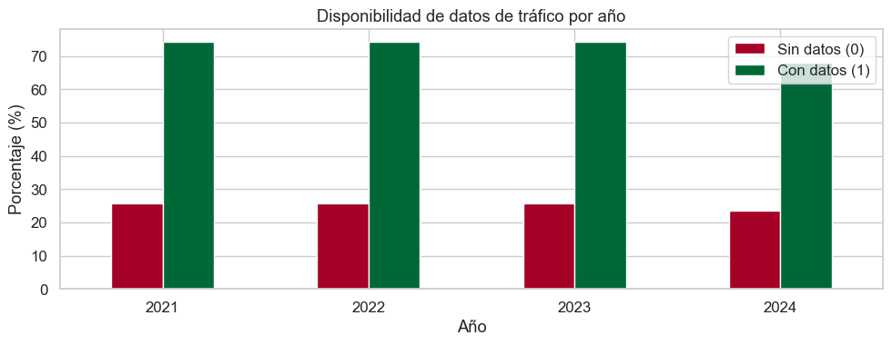

```python
# Distribución de disponibilidad de datos por año
_serie = df_trafico['infoDisponible']
if isinstance(_serie, pd.DataFrame):
    _serie = _serie.iloc[:, 0]
disponibilidad = _serie.groupby(df_trafico['_año']).value_counts(normalize=True).unstack() * 100
cols_validas = [c for c in [0, 1] if c in disponibilidad.columns]
disponibilidad = disponibilidad[cols_validas]
disponibilidad.columns = ['Sin datos (0)' if c == 0 else 'Con datos (1)' for c in disponibilidad.columns]

ax = disponibilidad.plot(kind='bar', figsize=(10, 4), colormap='RdYlGn')
ax.set_title('Disponibilidad de datos de tráfico por año')
ax.set_xlabel('Año')
ax.set_ylabel('Porcentaje (%)')
ax.set_xticklabels(ax.get_xticklabels(), rotation=0)
ax.legend(loc='upper right')
plt.tight_layout()
plt.show()
```

### Disponibilidad anual de datos

En el año 2024, se observa una ligera disminución en la tasa de registros con datos (68.1%), aunque la proporción de registros marcados explícitamente como 'Sin datos' (0) también disminuye levemente al 23.5%. Esta consistencia sugiere que las interrupciones en el servicio de los sensores no son eventos aleatorios aislados, sino que responden a un patrón de funcionamiento del sistema de monitorización que debe ser tenido en cuenta al agregar los datos temporalmente.

### 1.3 Patrones temporales del tráfico

```python
# Filtrar solo registros con datos disponibles
df_traf = df_trafico[df_trafico['infoDisponible'] == 1].copy()

# Variables temporales derivadas
df_traf['hora']           = df_traf['timestamp'].dt.hour
df_traf['dia_semana']     = df_traf['timestamp'].dt.dayofweek  # 0=Lunes
df_traf['dia_semana_str'] = df_traf['timestamp'].dt.day_name()
df_traf['mes']            = df_traf['timestamp'].dt.month
df_traf['fecha']          = df_traf['timestamp'].dt.date

print(f'Registros con datos disponibles: {len(df_traf):,}')
```

```
Registros con datos disponibles: 15,674,546
```

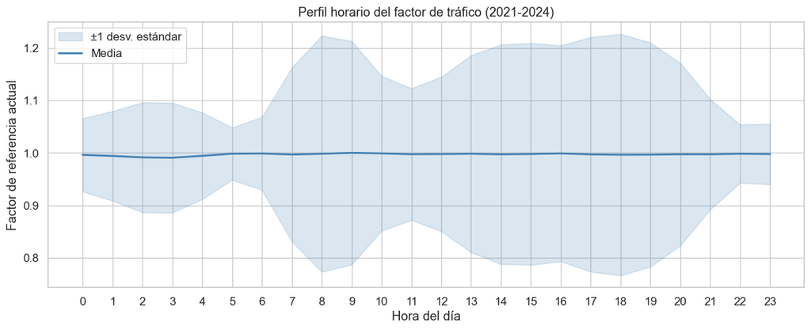

```python
# Perfil horario medio del factor de tráfico
df_traf['factorReferenciaActual'] = pd.to_numeric(df_traf['factorReferenciaActual'], errors='coerce')
perfil_horario = df_traf.groupby('hora')['factorReferenciaActual'].agg(['mean', 'std'])

fig, ax = plt.subplots(figsize=(12, 5))
ax.fill_between(
    perfil_horario.index,
    perfil_horario['mean'] - perfil_horario['std'],
    perfil_horario['mean'] + perfil_horario['std'],
    alpha=0.2, color='steelblue', label='±1 desv. estándar'
)
ax.plot(perfil_horario.index, perfil_horario['mean'], color='steelblue', linewidth=2, label='Media')
ax.set_title('Perfil horario del factor de tráfico (2021-2024)')
ax.set_xlabel('Hora del día')
ax.set_ylabel('Factor de referencia actual')
ax.set_xticks(range(24))
ax.legend()
plt.tight_layout()
plt.show()
```

### Análisis del perfil horario

La media horaria (línea azul) es prácticamente plana en 1.0 durante las 24 horas, lo que refleja que el factorReferenciaActual es un índice normalizado respecto al flujo libre. La clave está en la banda de desviación estándar: es estrecha de madrugada (0h–6h), se abre mucho entre las 8h y las 12h y de nuevo entre las 14h y las 20h, justo las horas de mayor tráfico. Esto significa que la variabilidad entre tramos y días es máxima en horas punta: hay tramos muy congestionados y tramos libres al mismo tiempo, lo que justifica modelar a nivel de tramo individual.

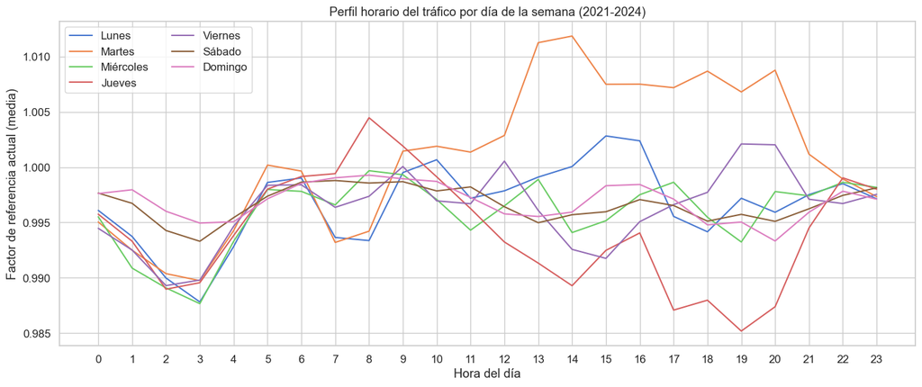

```python
# Perfil horario por día de la semana
orden_dias = ['Monday', 'Tuesday', 'Wednesday', 'Thursday', 'Friday', 'Saturday', 'Sunday']
etiquetas_dias = ['Lunes', 'Martes', 'Miércoles', 'Jueves', 'Viernes', 'Sábado', 'Domingo']

perfil_hora_dia = df_traf.groupby(['hora', 'dia_semana_str'])['factorReferenciaActual'].mean().unstack()
perfil_hora_dia = perfil_hora_dia[orden_dias]
perfil_hora_dia.columns = etiquetas_dias

fig, ax = plt.subplots(figsize=(14, 6))
perfil_hora_dia.plot(ax=ax, linewidth=1.5)
ax.set_title('Perfil horario del tráfico por día de la semana (2021-2024)')
ax.set_xlabel('Hora del día')
ax.set_ylabel('Factor de referencia actual (media)')
ax.set_xticks(range(24))
ax.legend(loc='upper left', ncol=2)
plt.tight_layout()
plt.show()
```

### Comparativa por días de la semana

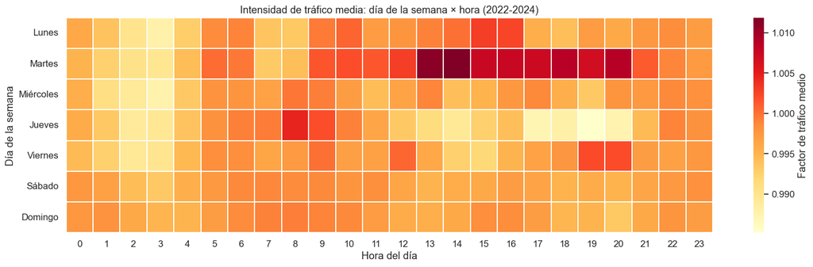

```python
# Heatmap hora × día de la semana
pivot = df_traf.groupby(['dia_semana', 'hora'])['factorReferenciaActual'].mean().unstack()
pivot.index = etiquetas_dias

fig, ax = plt.subplots(figsize=(16, 5))
sns.heatmap(
    pivot, ax=ax, cmap='YlOrRd', linewidths=0.3,
    cbar_kws={'label': 'Factor de tráfico medio'}
)
ax.set_title('Intensidad de tráfico media: día de la semana × hora (2022-2024)')
ax.set_xlabel('Hora del día')
ax.set_ylabel('Día de la semana')
plt.tight_layout()
plt.show()
```

### Análisis del mapa de calor: Día × Hora

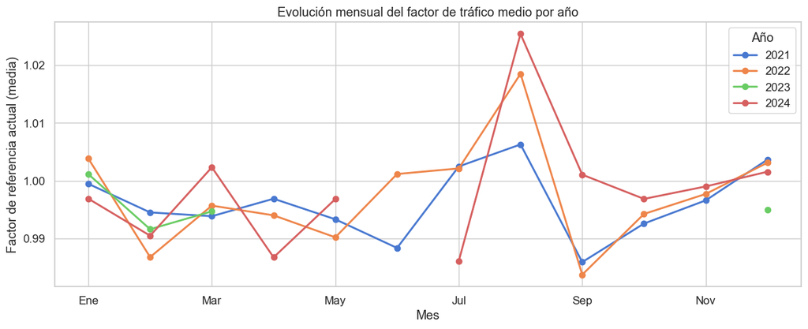

```python
# Patrón mensual
nombres_meses = ['Ene', 'Feb', 'Mar', 'Abr', 'May', 'Jun',
                 'Jul', 'Ago', 'Sep', 'Oct', 'Nov', 'Dic']

perfil_mensual = df_traf.groupby(['_año', 'mes'])['factorReferenciaActual'].mean().unstack(0)
perfil_mensual.index = nombres_meses[:len(perfil_mensual)]

fig, ax = plt.subplots(figsize=(12, 5))
perfil_mensual.plot(ax=ax, marker='o', linewidth=2)
ax.set_title('Evolución mensual del factor de tráfico medio por año')
ax.set_xlabel('Mes')
ax.set_ylabel('Factor de referencia actual (media)')
ax.legend(title='Año')
plt.tight_layout()
plt.show()
```

### 1.4 Análisis por tramos

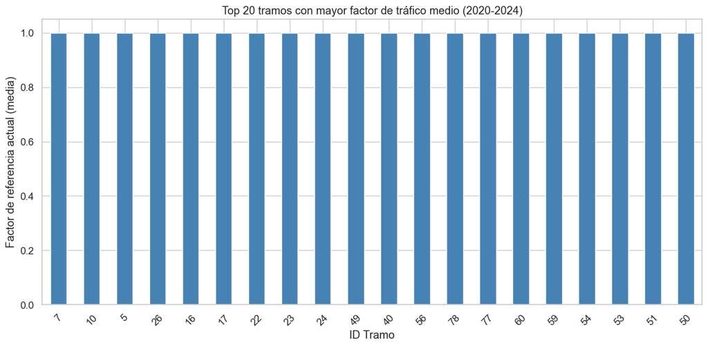

```python
# Top 20 tramos con mayor intensidad media
top_tramos = (
    df_traf.groupby('idTram')['factorReferenciaActual']
    .mean()
    .sort_values(ascending=False)
    .head(20)
)

fig, ax = plt.subplots(figsize=(12, 6))
top_tramos.plot(kind='bar', ax=ax, color='steelblue')
ax.set_title('Top 20 tramos con mayor factor de tráfico medio (2020-2024)')
ax.set_xlabel('ID Tramo')
ax.set_ylabel('Factor de referencia actual (media)')
ax.set_xticklabels(ax.get_xticklabels(), rotation=45)
plt.tight_layout()
plt.show()
```

### Análisis de los tramos de mayor intensidad

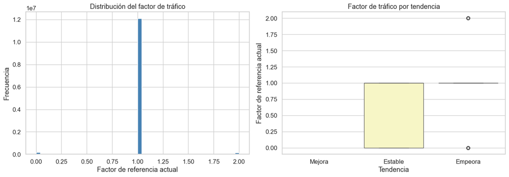

```python
# Distribución del factor de tráfico
fig, axes = plt.subplots(1, 2, figsize=(14, 5))

# Histograma
df_traf['factorReferenciaActual'].hist(bins=50, ax=axes[0], color='steelblue', edgecolor='white')
axes[0].set_title('Distribución del factor de tráfico')
axes[0].set_xlabel('Factor de referencia actual')
axes[0].set_ylabel('Frecuencia')

# Boxplot por tendencia
tend_labels = {0.0: 'Estable', 1.0: 'Empeora', -1.0: 'Mejora'}
df_traf_tend = df_traf[df_traf['tendencia'].notna()].copy()
df_traf_tend['tendencia_label'] = df_traf_tend['tendencia'].map(tend_labels)

orden_tend = ['Mejora', 'Estable', 'Empeora']
sns.boxplot(
    data=df_traf_tend, x='tendencia_label', y='factorReferenciaActual',
    order=orden_tend, ax=axes[1], palette='RdYlGn_r'
)
axes[1].set_title('Factor de tráfico por tendencia')
axes[1].set_xlabel('Tendencia')
axes[1].set_ylabel('Factor de referencia actual')

plt.tight_layout()
plt.show()
```

### Distribución y tendencias del tráfico

Panel izquierdo: el histograma muestra una distribución extremadamente concentrada alrededor de 1.0, con frecuencias en el eje Y de hasta 12 millones. Hay dos pequeñas colas en 0.0 y 2.0 que corresponden a valores extremos (congestión severa o datos anómalos), pero son casi invisibles a esta escala. El 99%+ de los datos vive entre 0.9 y 1.1.

## 2. Red viaria — Tramos

Definición geográfica de los tramos de la red viaria principal de Barcelona.

```python
# Cargar tramos
df_trams = pd.read_csv(PATH_TRAMS / 'transit_relacio_trams.csv')
print(f'Dimensiones: {df_trams.shape}')
df_trams.head(10)
```

```
Dimensiones: (527, 3)
```

|  | Tram | Descripció | Coordenades |
| --- | --- | --- | --- |
| 0 | 1 | Diagonal (Ronda de Dalt a Doctor Marañón) | 2.11203535639414,41.3841912394771,2.1015028628... |
| 1 | 2 | Diagonal (Doctor Marañón a Ronda de Dalt) | 2.111944376806616,41.38446666680338,2.10159408... |
| 2 | 3 | Diagonal (Doctor Marañón a Pl. Pius XII) | 2.112093343037027,41.38422850920645,2.12264979... |
| 3 | 4 | Diagonal (Pl. Pius XII a Doctor Marañón) | 2.122592049318304,41.38719094189204,2.11196902... |
| 4 | 5 | Diagonal (Pl. Pius XII a Pl. Maria Cristina) | 2.122657659295115,41.38694195794678,2.12755961... |
| 5 | 6 | Diagonal (Pl. Maria Cristina a Pl. Pius XII) | 2.127445471496177,41.38841486943499,2.12260182... |
| 6 | 7 | Diagonal (Pl. Maria Cristina a Numància) | 2.132701524574889,41.38946673844387,2.12754890... |
| 7 | 8 | Diagonal (Numància a Pl. Maria Cristina) | 2.132462297581474,41.38967891982529,2.12746219... |
| 8 | 9 | Diagonal (Entença a Francesc Macià) | 2.137322638833081,41.39061820620348,2.14394391... |
| 9 | 10 | Diagonal (Francesc Macià a Entença) | 2.144060999786239,41.39265861540969,2.13711452... |

```python
# Extraer coordenadas de inicio y fin (los tramos son polilíneas con N puntos)
def extraer_coords(coord_str):
    vals = [float(v) for v in coord_str.split(',')]
    return vals[0], vals[1], vals[-2], vals[-1]

coords = df_trams['Coordenades'].apply(extraer_coords)
df_trams[['lon_ini', 'lat_ini', 'lon_fi', 'lat_fi']] = pd.DataFrame(coords.tolist(), index=df_trams.index)

# Punto central del tramo
df_trams['lat_centre'] = (df_trams['lat_ini'] + df_trams['lat_fi']) / 2
df_trams['lon_centre'] = (df_trams['lon_ini'] + df_trams['lon_fi']) / 2

print(f'Tramos con coordenadas válidas: {df_trams["lat_centre"].notna().sum()}')
df_trams[['Tram', 'Descripció', 'lat_centre', 'lon_centre']].head()
```

```
Tramos con coordenadas válidas: 527
```

|  | Tram | Descripció | lat_centre | lon_centre |
| --- | --- | --- | --- | --- |
| 0 | 1 | Diagonal (Ronda de Dalt a Doctor Marañón) | 41.3829 | 2.1068 |
| 1 | 2 | Diagonal (Doctor Marañón a Ronda de Dalt) | 41.3832 | 2.1068 |
| 2 | 3 | Diagonal (Doctor Marañón a Pl. Pius XII) | 41.3856 | 2.1174 |
| 3 | 4 | Diagonal (Pl. Pius XII a Doctor Marañón) | 41.3858 | 2.1173 |
| 4 | 5 | Diagonal (Pl. Pius XII a Pl. Maria Cristina) | 41.3876 | 2.1251 |

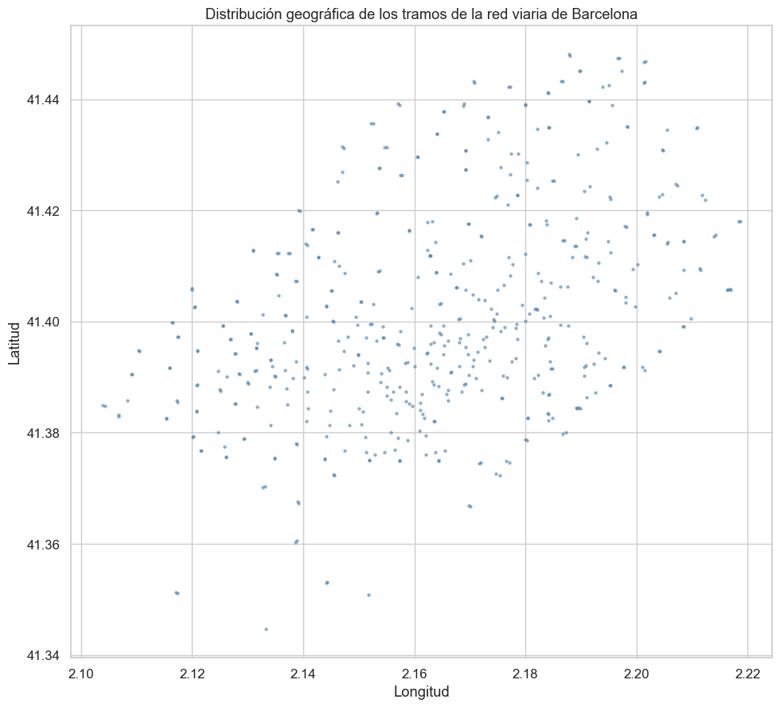

```python
# Mapa de dispersión de los tramos
fig, ax = plt.subplots(figsize=(10, 10))
ax.scatter(
    df_trams['lon_centre'], df_trams['lat_centre'],
    s=5, alpha=0.5, color='steelblue'
)
ax.set_title('Distribución geográfica de los tramos de la red viaria de Barcelona')
ax.set_xlabel('Longitud')
ax.set_ylabel('Latitud')
ax.set_aspect('equal')
plt.tight_layout()
plt.show()
```

### Distribución geográfica de los tramos

```python
# Cargar relación tramo-itinerario
df_tram_iti = pd.read_csv(PATH_TRAM_ITIS / 'transit_relacio_tram_per_itinerari.csv')
print(f'Dimensiones: {df_tram_iti.shape}')
print(f'Itinerarios únicos: {df_tram_iti["Itinerari"].nunique()}')
print(f'Tramos únicos: {df_tram_iti["Tram"].nunique()}')
df_tram_iti.head()
```

```
Dimensiones: (286, 3)
Itinerarios únicos: 78
Tramos únicos: 209
```

|  | Itinerari | Tram | Descripció |
| --- | --- | --- | --- |
| 0 | 1 | 0 | Aragó de Meridiana a Pau Claris |
| 1 | 1 | 271 | Aragó (Meridiana a Cartagena) |
| 2 | 1 | 272 | Aragó (Cartagena a Diagonal) |
| 3 | 1 | 273 | Aragó (Diagonal a Passeig de Sant Joan) |
| 4 | 1 | 274 | Aragó (Passeig de Sant Joan a Pau Claris) |

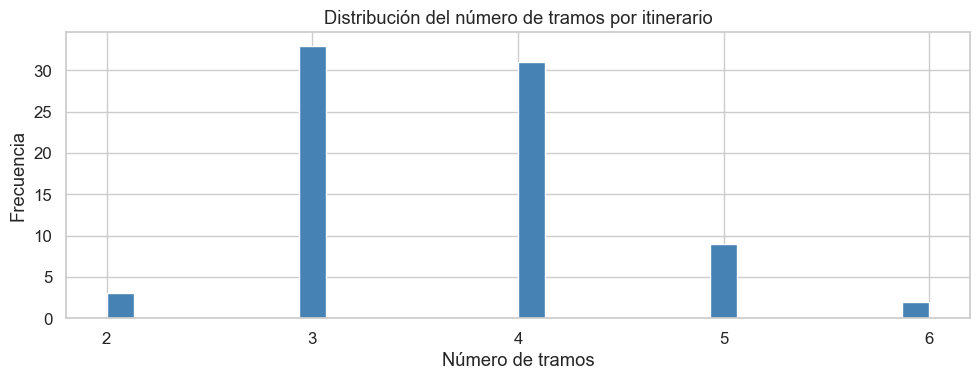

```python
# Número de tramos por itinerario
tramos_por_itinerario = df_tram_iti.groupby('Itinerari')['Tram'].count()

fig, ax = plt.subplots(figsize=(10, 4))
tramos_por_itinerario.plot(kind='hist', bins=30, ax=ax, color='steelblue', edgecolor='white')
ax.set_title('Distribución del número de tramos por itinerario')
ax.set_xlabel('Número de tramos')
ax.set_ylabel('Frecuencia')
ax.xaxis.set_major_locator(plt.MaxNLocator(integer=True))
plt.tight_layout()
plt.show()
```

### Análisis de la estructura de los itinerarios

La mayoría de los itinerarios agrupan 3 o 4 tramos (barras más altas, ~32 y ~31 itinerarios respectivamente). Los itinerarios de 2 tramos son raros (3 casos) y los de 6 también (2 casos). Esta distribución sugiere que los itinerarios definen rutas cortas y homogéneas dentro del grafo vial, y que agrupar los datos a nivel de itinerario (en lugar de tramo) perdería granularidad sin ganar demasiado.

## 3. Eventos urbanos — Festivales y Fiestas

```python
def cargar_festivales(path):
    """Carga y concatena todos los ficheros de festivales/fiestas."""
    archivos = sorted(path.glob('*.csv'))
    dfs = []
    for f in archivos:
        try:
            df = pd.read_csv(f, encoding='utf-8', sep=',', on_bad_lines='skip')
            dfs.append(df)
        except Exception:
            try:
                df = pd.read_csv(f, encoding='latin-1', sep=',', on_bad_lines='skip')
                dfs.append(df)
            except Exception as e:
                print(f'Error en {f.name}: {e}')
    return pd.concat(dfs, ignore_index=True)

df_festivales = cargar_festivales(PATH_FESTIVALES)
print(f'Dimensiones festivales: {df_festivales.shape}')
df_festivales.head()
```

```
Dimensiones festivales: (61, 12)
```

|  | Ambit | Titularitat | Tipus | Edicio | Festa | DataInici | DataFi | Assistents | Espai | Organitzador | Nota | Any |
| --- | --- | --- | --- | --- | --- | --- | --- | --- | --- | --- | --- | --- |
| 0 | Festes i tradicions | Ajuntament de Barcelona | Festes | NaN | Cavalcada de Reis | 05/01/2021 | 05/01/2021 | 40000.0000 | Diversos espais de la ciutat | Institut de Cultura. Ajuntament de Barcelona | La Cavalcada de Reis del 2021, en motiu de la ... | 2021 |
| 1 | Festes i tradicions | Mixta | Festes | NaN | Carnaval | 11/02/2021 | 17/02/2021 | NaN | NaN | NaN | A causa de la crisi sanitària de la covid-19, ... | 2021 |
| 2 | Festes i tradicions | Ajuntament de Barcelona | Festes | NaN | Festes de Santa Eulàlia | 12/02/2021 | 14/02/2021 | NaN | Diversos espais de la ciutat | Institut de Cultura. Ajuntament de Barcelona | A causa de la crisi sanitària de la covid-19, ... | 2021 |
| 3 | Festes i tradicions | Mixta | Festes | NaN | Sant Medir | 03/03/2021 | 03/03/2021 | NaN | NaN | NaN | A causa de la crisi sanitària de la covid-19, ... | 2021 |
| 4 | Festes i tradicions | Mixta | Festes | NaN | Diada de Sant Jordi | 23/04/2021 | 23/04/2021 | NaN | NaN | NaN | A causa de la crisi sanitària de la covid-19, ... | 2021 |

```python
# Parsear fechas
for col in ['DataInici', 'DataFi']:
    df_festivales[col] = pd.to_datetime(df_festivales[col], format='%d/%m/%Y', errors='coerce')

df_festivales['duracion_dias'] = (df_festivales['DataFi'] - df_festivales['DataInici']).dt.days + 1

# Convertir asistentes a numérico
df_festivales['Assistents'] = pd.to_numeric(
    df_festivales['Assistents'].astype(str).str.replace('[^0-9]', '', regex=True),
    errors='coerce'
)

print(f'Rango temporal: {df_festivales["DataInici"].min().year} - {df_festivales["DataInici"].max().year}')
print(f'\nEstadísticas de asistentes:')
print(df_festivales['Assistents'].describe())
```

```
Rango temporal: 2021 - 2024

Estadísticas de asistentes:
count         23.0000
mean     2581059.1304
std      3731535.1975
min         8620.0000
25%       140000.0000
50%       937620.0000
75%      3151230.0000
max     11057190.0000
Name: Assistents, dtype: float64
```

### Asistencia a eventos y festivales

Las estadísticas de asistentes revelan la magnitud y la heterogeneidad de los eventos culturales en Barcelona. Con una media que supera los 2.5 millones de personas por evento registrado (aunque influenciada por grandes festivales que duran varios días), queda patente el enorme potencial de impacto sobre la red de transporte. La desviación estándar es significativamente alta, lo que indica una gran disparidad entre las fiestas locales menores y los grandes hitos del calendario como La Mercè o la Cavalcada de Reis.

El hecho de que el 50% de los eventos (mediana) atraiga a casi un millón de personas sugiere que la mayoría de los festivales analizados son eventos de gran escala con capacidad para alterar los flujos de tráfico habituales. Para el modelado predictivo, esta variable será crucial, ya que el volumen de asistentes probablemente presente una correlación directa con el incremento del factor de tráfico en los tramos adyacentes a los recintos de celebración.

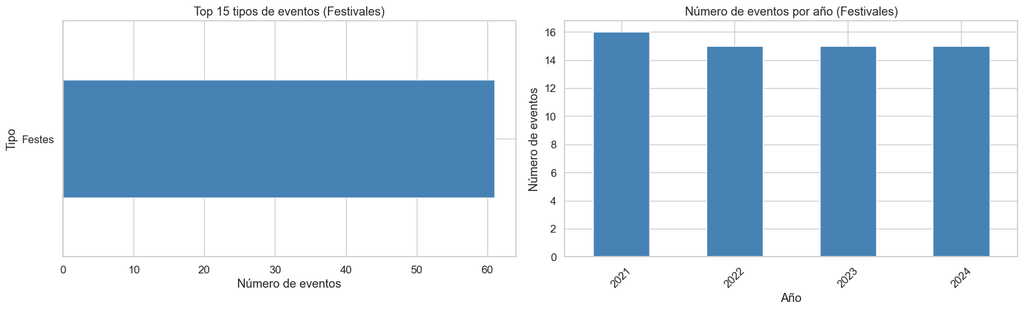

```python
# Tipos de eventos
fig, axes = plt.subplots(1, 2, figsize=(16, 5))

# Por tipo
tipos = df_festivales['Tipus'].value_counts().head(15)
tipos.plot(kind='barh', ax=axes[0], color='steelblue')
axes[0].set_title('Top 15 tipos de eventos (Festivales)')
axes[0].set_xlabel('Número de eventos')
axes[0].set_ylabel('Tipo')
axes[0].invert_yaxis()

# Por año
eventos_por_año = df_festivales.groupby('Any').size()
eventos_por_año.plot(kind='bar', ax=axes[1], color='steelblue', edgecolor='white')
axes[1].set_title('Número de eventos por año (Festivales)')
axes[1].set_xlabel('Año')
axes[1].set_ylabel('Número de eventos')
axes[1].set_xticklabels(axes[1].get_xticklabels(), rotation=45)

plt.tight_layout()
plt.show()
```

### Distribución de eventos festivos

Panel izquierdo: solo aparece una categoría: "Festes", con unos 62 registros. La agenda de festivales del Ajuntament no distingue subtipos — todos los eventos son "Festes". Esto limita mucho la utilidad de este dataset para el modelado, ya que no hay forma de saber si un festival es musical, deportivo o gastronómico.

Panel derecho: el número de festivales es muy estable entre años: ~16 en 2021 y ~15 en 2022, 2023 y 2024. No hay efecto pandemia ni pico en ningún año. Es una fuente de datos pequeña y muy regular, más una señal de calendario que una variable predictiva.

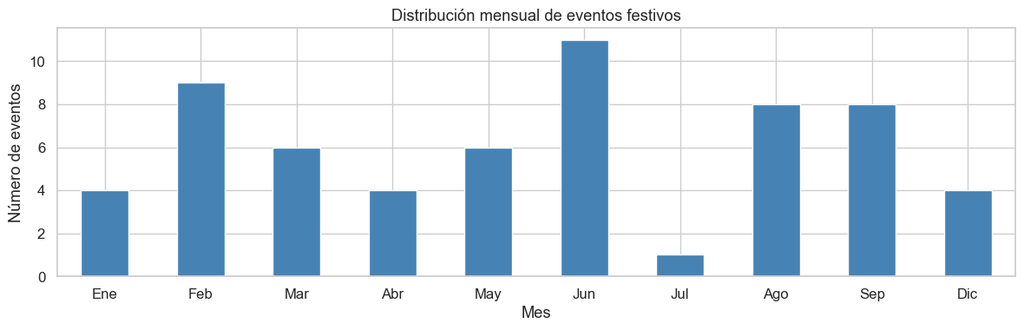

```python
# Distribución mensual de eventos
df_festivales_validos = df_festivales[df_festivales['DataInici'].notna()].copy()
df_festivales_validos['mes_inicio'] = df_festivales_validos['DataInici'].dt.month

nombres_meses = ['Ene', 'Feb', 'Mar', 'Abr', 'May', 'Jun',
                 'Jul', 'Ago', 'Sep', 'Oct', 'Nov', 'Dic']

conteo = df_festivales_validos['mes_inicio'].value_counts().sort_index()
etiquetas = [nombres_meses[m - 1] for m in conteo.index]

fig, ax = plt.subplots(figsize=(12, 4))
conteo.plot(kind='bar', ax=ax, color='steelblue', edgecolor='white')
ax.set_title('Distribución mensual de eventos festivos')
ax.set_xlabel('Mes')
ax.set_ylabel('Número de eventos')
ax.set_xticklabels(etiquetas, rotation=0)
plt.tight_layout()
plt.show()
```

### Estacionalidad de los eventos

Junio es el mes con más festivales (~11), seguido de febrero (~9) y agosto–septiembre (~8). Julio es el mes más flojo (solo 1 evento). Octubre y noviembre están ausentes del gráfico, posiblemente porque no hay festivales catalogados en esos meses. El patrón es irregular y no tiene una estacionalidad obvia.

```python
# Top eventos por asistentes
top_asistentes = df_festivales[df_festivales['Assistents'].notna()].nlargest(15, 'Assistents')
top_asistentes[['Festa', 'Any', 'Assistents', 'duracion_dias']].reset_index(drop=True).style.format({'Assistents': '{:,.0f}', 'duracion_dias': '{:.0f}'})
```

|  | Festa | Any | Assistents | duracion_dias |
| --- | --- | --- | --- | --- |
| 0 | La Mercè | 2023 | 11,057,190 | 4 |
| 1 | La Mercè | 2022 | 10,420,970 | 4 |
| 2 | La Mercè | 2024 | 10,331,810 | 5 |
| 3 | Cavalcada de Reis | 2023 | 7,500,000 | 1 |
| 4 | Cavalcada de Reis | 2024 | 6,000,000 | 1 |
| 5 | Cavalcada de Reis | 2022 | 4,250,000 | 1 |
| 6 | La Mercè | 2021 | 2,052,460 | 4 |
| 7 | Espectacle Nit de Cap d'Any | 2022 | 1,200,000 | 1 |
| 8 | Espectacle Nit de Cap d'Any | 2023 | 1,200,000 | 1 |
| 9 | Espectacle Nit de Cap d'Any | 2024 | 1,200,000 | 1 |
| 10 | Nit dels Museus | 2024 | 1,009,030 | 1 |
| 11 | Nit dels Museus | 2022 | 937,620 | 1 |
| 12 | Nit dels Museus | 2023 | 937,570 | 1 |
| 13 | Cavalcada de Reis | 2021 | 400,000 | 1 |
| 14 | Nit dels Museus | 2021 | 302,300 | 1 |

## 4. Agenda cultural y de actividades

```python
# Los ficheros de agenda están en UTF-16 LE (con BOM)
df_agenda_cultural = pd.read_csv(
    PATH_AGENDA_C / 'opendatabcn_agenda-cultural-csv.csv',
    encoding='utf-16'
)
print(f'Agenda cultural — Dimensiones: {df_agenda_cultural.shape}')
print(f'Columnas principales: {df_agenda_cultural.columns.tolist()[:10]}')
df_agenda_cultural.head(3)
```

```
Agenda cultural — Dimensiones: (4762, 40)
Columnas principales: ['register_id', 'name', 'institution_id', 'institution_name', 'created', 'modified', 'addresses_roadtype_id', 'addresses_roadtype_name', 'addresses_road_id', 'addresses_road_name']
```

|  | register_id | name | institution_id | institution_name | created | modified | addresses_roadtype_id | addresses_roadtype_name | addresses_road_id | addresses_road_name | addresses_start_street_number | addresses_end_street_number | addresses_neighborhood_id | addresses_neighborhood_name | addresses_district_id | addresses_district_name | addresses_zip_code | addresses_town | addresses_main_address | addresses_type | values_id | values_attribute_id | values_category | values_attribute_name | values_value | values_outstanding | values_description | secondary_filters_id | secondary_filters_name | … |
| --- | --- | --- | --- | --- | --- | --- | --- | --- | --- | --- | --- | --- | --- | --- | --- | --- | --- | --- | --- | --- | --- | --- | --- | --- | --- | --- | --- | --- | --- | --- |
| 0 | 99400698723 | Concert "Pur Funk: Clarence Bekker Band" | NaN | NaN | 2022-09-30T12:58:50.560970+02:00 | 2026-03-25T10:24:33.312669+01:00 | NaN | NaN | 276001.0000 | Plaça Reial | 17.0000 | NaN | 2.0000 | el Barri Gòtic | 1.0000 | Ciutat Vella | 8002.0000 | Barcelona | True | NaN | NaN | NaN | NaN | NaN | NaN | NaN | NaN | NaN | NaN | … |
| 1 | 99400711364 | Taller 'Dibuix: Aquarel·la II (intermedi)' | NaN | NaN | 2023-04-25T14:41:01.697548+02:00 | 2026-03-17T14:52:04.094822+01:00 | NaN | NaN | 213001.0000 | C Mir Geribert | 8.0000 | NaN | 15.0000 | Hostafrancs | 3.0000 | Sants-Montjuïc | 8014.0000 | BARCELONA | True | NaN | NaN | NaN | NaN | NaN | NaN | NaN | NaN | NaN | NaN | … |
| 2 | 99400737097 | Exposició 'Sortir al dia. El Llibre dels Morts... | NaN | NaN | 2024-05-31T10:02:10.360576+02:00 | 2026-02-01T17:25:08.123401+01:00 | NaN | NaN | 350308.0000 | Carrer de València | 284.0000 | NaN | 7.0000 | la Dreta de l'Eixample | 2.0000 | Eixample | 8007.0000 | Barcelona | True | NaN | NaN | NaN | NaN | NaN | NaN | NaN | NaN | NaN | NaN | … |

```python
df_agenda_act = pd.read_csv(
    PATH_AGENDA_A / 'opendatabcn_agenda-csv.csv',
    encoding='utf-16'
)
print(f'Agenda actividades — Dimensiones: {df_agenda_act.shape}')
df_agenda_act.head(3)
```

```
Agenda actividades — Dimensiones: (5747, 40)
```

|  | register_id | name | institution_id | institution_name | created | modified | addresses_roadtype_id | addresses_roadtype_name | addresses_road_id | addresses_road_name | addresses_start_street_number | addresses_end_street_number | addresses_neighborhood_id | addresses_neighborhood_name | addresses_district_id | addresses_district_name | addresses_zip_code | addresses_town | addresses_main_address | addresses_type | values_id | values_attribute_id | values_category | values_attribute_name | values_value | values_outstanding | values_description | secondary_filters_id | secondary_filters_name | … |
| --- | --- | --- | --- | --- | --- | --- | --- | --- | --- | --- | --- | --- | --- | --- | --- | --- | --- | --- | --- | --- | --- | --- | --- | --- | --- | --- | --- | --- | --- | --- |
| 0 | 99400686502 | Espectacle "El llapis màgic", a càrrerc de Joa... | NaN | NaN | 2022-02-23T09:59:57.702512+01:00 | 2026-03-27T09:59:01.981934+01:00 | NaN | NaN | 123408.0000 | Plaça de Lesseps | 20.0000 | NaN | 28.0000 | Vallcarca i els Penitents | 6.0000 | Gràcia | 8023.0000 | Barcelona | True | NaN | NaN | NaN | NaN | NaN | NaN | NaN | NaN | NaN | NaN | … |
| 1 | 99400698723 | Concert "Pur Funk: Clarence Bekker Band" | NaN | NaN | 2022-09-30T12:58:50.560970+02:00 | 2026-03-25T10:24:33.312669+01:00 | NaN | NaN | 276001.0000 | Plaça Reial | 17.0000 | NaN | 2.0000 | el Barri Gòtic | 1.0000 | Ciutat Vella | 8002.0000 | Barcelona | True | NaN | NaN | NaN | NaN | NaN | NaN | NaN | NaN | NaN | NaN | … |
| 2 | 99400726116 | Programació Campanya Vacances Estiu 2026 | NaN | NaN | 2023-12-19T14:20:07.804686+01:00 | 2026-03-23T10:49:32.372306+01:00 | NaN | NaN | NaN | NaN | NaN | NaN | NaN | NaN | NaN | NaN | NaN | Barcelona | True | NaN | NaN | NaN | NaN | NaN | NaN | NaN | NaN | NaN | NaN | … |

```python
def procesar_agenda(df, nombre):
    """Extrae y limpia las columnas relevantes de las agendas."""
    cols_relevantes = [
        'register_id', 'name',
        'addresses_district_name', 'addresses_neighborhood_name',
        'geo_epgs_4326_lat', 'geo_epgs_4326_lon',
        'start_date', 'end_date'
    ]
    cols_disponibles = [c for c in cols_relevantes if c in df.columns]
    df_clean = df[cols_disponibles].copy()

    # Parsear fechas
    for col in ['start_date', 'end_date']:
        if col in df_clean.columns:
            df_clean[col] = pd.to_datetime(df_clean[col], errors='coerce', utc=True)
            df_clean[col] = df_clean[col].dt.tz_localize(None)

    print(f'{nombre}: {len(df_clean):,} eventos')
    if 'start_date' in df_clean.columns:
        validos = df_clean['start_date'].notna().sum()
        print(f'  Con fecha de inicio: {validos:,} ({validos/len(df_clean)*100:.1f}%)')
    return df_clean

df_agenda_c_clean = procesar_agenda(df_agenda_cultural, 'Agenda Cultural')
df_agenda_a_clean = procesar_agenda(df_agenda_act, 'Agenda Actividades')
```

```
Agenda Cultural: 4,762 eventos
  Con fecha de inicio: 4,739 (99.5%)
Agenda Actividades: 5,747 eventos
  Con fecha de inicio: 5,641 (98.2%)
```

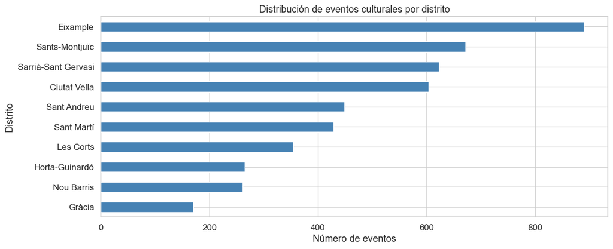

```python
# Distribución por distrito (agenda cultural)
if 'addresses_district_name' in df_agenda_c_clean.columns:
    distritos = df_agenda_c_clean['addresses_district_name'].value_counts().head(12)

    fig, ax = plt.subplots(figsize=(12, 5))
    distritos.plot(kind='barh', ax=ax, color='steelblue')
    ax.set_title('Distribución de eventos culturales por distrito')
    ax.set_xlabel('Número de eventos')
    ax.set_ylabel('Distrito')
    ax.invert_yaxis()
    plt.tight_layout()
    plt.show()
```

### Distribución por distritos

El gráfico de eventos culturales revela una centralización significativa de la actividad en distritos clave como el **Eixample**, **Sants-Montjuïc** y **Ciutat Vella**. El predominio del Eixample es particularmente relevante para nuestro modelo, ya que es un distrito central por el que transitan la mayoría de los itinerarios principales analizados en la sección de tráfico.

Esta concentración geográfica sugiere que el impacto de la agenda cultural en la fluidez del tráfico será espacialmente heterogéneo. Los distritos con mayor volumen de eventos probablemente actúen como focos de congestión localizada, mientras que en distritos con menor actividad, como Gràcia o Nou Barris, los patrones de tráfico podrían verse menos afectados por la programación cultural diaria y responder más a la movilidad residencial o laboral estándar.

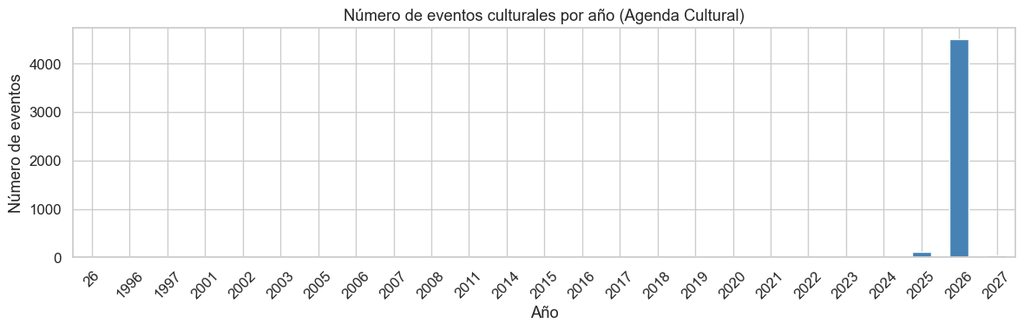

```python
# Distribución temporal de eventos de la agenda
if 'start_date' in df_agenda_c_clean.columns:
    agenda_con_fecha = df_agenda_c_clean[df_agenda_c_clean['start_date'].notna()].copy()
    agenda_con_fecha['año'] = agenda_con_fecha['start_date'].dt.year

    fig, ax = plt.subplots(figsize=(12, 4))
    agenda_con_fecha['año'].value_counts().sort_index().plot(
        kind='bar', ax=ax, color='steelblue', edgecolor='white'
    )
    ax.set_title('Número de eventos culturales por año (Agenda Cultural)')
    ax.set_xlabel('Año')
    ax.set_ylabel('Número de eventos')
    ax.set_xticklabels(ax.get_xticklabels(), rotation=45)
    plt.tight_layout()
    plt.show()
```

### Distribución temporal de la agenda

Este gráfico es el más llamativo del cuaderno por su anomalía: casi todos los años históricos (1996–2024) tienen cero eventos registrados, y de repente 2026 tiene más de 4.500 eventos y 2025 algo más de 100. Esto no significa que en 2026 haya más eventos — significa que la Agenda Cultural del Ajuntament almacena las fechas tal como fueron introducidas, y muchos eventos futuros ya estaban registrados con fecha 2025–2026. La fuente no es utilizable para el periodo 2021–2024 sin filtrado previo.

## 5. Meteorología

```python
# Cargar datos meteorológicos (format detallado por estación)
meteo_files = sorted(PATH_METEO.glob('*MeteoCat_Detall_Estacions*.csv'))
dfs_meteo = []
for f in meteo_files:
    df = pd.read_csv(f, encoding='utf-8', on_bad_lines='skip')
    dfs_meteo.append(df)

df_meteo = pd.concat(dfs_meteo, ignore_index=True)
df_meteo['DATA_LECTURA'] = pd.to_datetime(df_meteo['DATA_LECTURA'], errors='coerce')

print(f'Dimensiones: {df_meteo.shape}')
print(f'Estaciones: {df_meteo["CODI_ESTACIO"].unique()}')
print(f'Variables (ACRÒNIM): {df_meteo["ACRÒNIM"].unique()}')
df_meteo.head()
```

```
Dimensiones: (73929, 5)
Estaciones: <ArrowStringArray>
['D5', 'X2', 'X4', 'X8']
Length: 4, dtype: str
Variables (ACRÒNIM): <ArrowStringArray>
[    'TM',     'TX',     'TN',    'HRM',    'HRX',    'HRN',     'PM',
     'PX',     'PN',    'PPT',  'RS24h',  'VVM10',  'DVM10',  'VVX10',
 'DVVX10']
Length: 15, dtype: str
```

|  | DATA_LECTURA | DATA_EXTREM | CODI_ESTACIO | ACRÒNIM | VALOR |
| --- | --- | --- | --- | --- | --- |
| 0 | 2021-01-01 | NaN | D5 | TM | 5.3000 |
| 1 | 2021-01-01 | 13:06:00 | D5 | TX | 6.5000 |
| 2 | 2021-01-01 | 23:56:00 | D5 | TN | 3.1000 |
| 3 | 2021-01-01 | NaN | D5 | HRM | 77.0000 |
| 4 | 2021-01-01 | 10:36:00 | D5 | HRX | 88.0000 |

```python
# Significado de acrónimos meteorológicos
acro_desc = {
    'TM': 'Temperatura media (°C)',
    'TX': 'Temperatura máxima (°C)',
    'TN': 'Temperatura mínima (°C)',
    'PPT': 'Precipitación total (mm)',
    'HRM': 'Humedad relativa media (%)',
    'VVM10': 'Velocidad media del viento (m/s)',
    'DVM': 'Dirección media del viento (°)',
    'RS': 'Radiación solar (MJ/m²)',
    'EV': 'Evapotranspiración (mm)',
}
df_acro = pd.DataFrame(list(acro_desc.items()), columns=['ACRÒNIM', 'Descripción'])
df_acro
```

|  | ACRÒNIM | Descripción |
| --- | --- | --- |
| 0 | TM | Temperatura media (°C) |
| 1 | TX | Temperatura máxima (°C) |
| 2 | TN | Temperatura mínima (°C) |
| 3 | PPT | Precipitación total (mm) |
| 4 | HRM | Humedad relativa media (%) |
| 5 | VVM10 | Velocidad media del viento (m/s) |
| 6 | DVM | Dirección media del viento (°) |
| 7 | RS | Radiación solar (MJ/m²) |
| 8 | EV | Evapotranspiración (mm) |

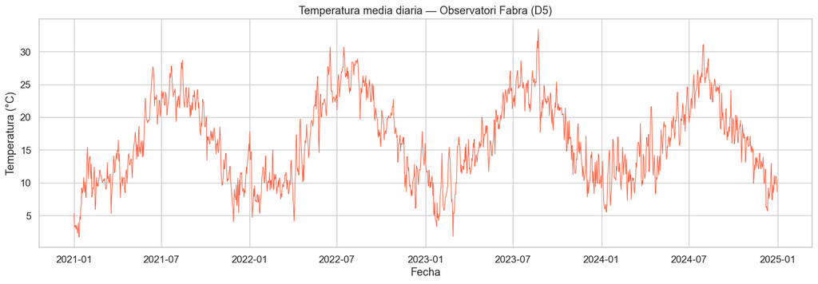

```python
# Temperatura media histórica (estación D5 - Observatori Fabra)
df_temp = df_meteo[
    (df_meteo['CODI_ESTACIO'] == 'D5') &
    (df_meteo['ACRÒNIM'] == 'TM') &
    (df_meteo['DATA_LECTURA'].notna())
].copy()

df_temp = df_temp.sort_values('DATA_LECTURA')

fig, ax = plt.subplots(figsize=(14, 5))
ax.plot(df_temp['DATA_LECTURA'], df_temp['VALOR'], color='tomato', linewidth=0.8)
ax.set_title('Temperatura media diaria — Observatori Fabra (D5)')
ax.set_xlabel('Fecha')
ax.set_ylabel('Temperatura (°C)')
plt.tight_layout()
plt.show()
```

### Evolución de la temperatura

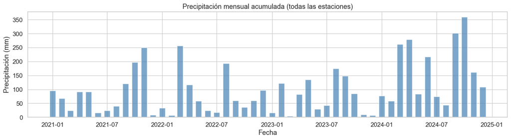

```python
# Precipitación mensual acumulada
df_ppt = df_meteo[
    (df_meteo['ACRÒNIM'] == 'PPT') &
    (df_meteo['DATA_LECTURA'].notna())
].copy()
df_ppt['año_mes'] = df_ppt['DATA_LECTURA'].dt.to_period('M')
ppt_mensual = df_ppt.groupby('año_mes')['VALOR'].sum().reset_index()
ppt_mensual['año_mes_dt'] = ppt_mensual['año_mes'].dt.to_timestamp()

fig, ax = plt.subplots(figsize=(14, 4))
ax.bar(ppt_mensual['año_mes_dt'], ppt_mensual['VALOR'], width=20, color='steelblue', alpha=0.7)
ax.set_title('Precipitación mensual acumulada (todas las estaciones)')
ax.set_xlabel('Fecha')
ax.set_ylabel('Precipitación (mm)')
plt.tight_layout()
plt.show()
```

## 6. Accidentes de tráfico

```python
# Cargar accidentes (2018-2024)
acc_files = sorted(PATH_ACCIDENTES.glob('20[12][0-9]_accidents_*.csv'))
dfs_acc = []
for f in acc_files:
    try:
        df = pd.read_csv(f, encoding='utf-8-sig', on_bad_lines='skip')
        dfs_acc.append(df)
    except Exception as e:
        print(f'Error en {f.name}: {e}')

df_acc = pd.concat(dfs_acc, ignore_index=True)
print(f'Dimensiones: {df_acc.shape}')
print(f'Columnas: {df_acc.columns.tolist()}')
df_acc.head(3)
```

```
Dimensiones: (31254, 23)
Columnas: ['Numero_expedient', 'Codi_districte', 'Nom_districte', 'Codi_barri', 'Nom_barri', 'Codi_carrer', 'Nom_carrer', 'Num_postal_caption', 'Descripcio_dia_setmana', 'NK_Any', 'Mes_any', 'Nom_mes', 'Dia_mes', 'Hora_dia', 'Descripcio_torn', 'Descripcio_tipus_accident', 'Coordenada_UTM_X_ED50', 'C…
```

|  | Numero_expedient | Codi_districte | Nom_districte | Codi_barri | Nom_barri | Codi_carrer | Nom_carrer | Num_postal_caption | Descripcio_dia_setmana | NK_Any | Mes_any | Nom_mes | Dia_mes | Hora_dia | Descripcio_torn | Descripcio_tipus_accident | Coordenada_UTM_X_ED50 | Coordenada_UTM_Y_ED50 | Longitud_WGS84 | Latitud_WGS84 | Longitud | Latitud | Num_postal |
| --- | --- | --- | --- | --- | --- | --- | --- | --- | --- | --- | --- | --- | --- | --- | --- | --- | --- | --- | --- | --- | --- | --- | --- |
| 0 | 2021S006247 | -1 | Desconegut | -1 | Desconegut | -1.0000 | Glòries Catalanes ... | Desconegut | Dimecres | 2021 | 11 | Novembre | 3 | 12 | Matí | Caiguda interior vehicle | -1.0000 | -1.0000 | NaN | NaN | NaN | NaN | NaN |
| 1 | 2021S000858 | -1 | Desconegut | -1 | Desconegut | -1.0000 | Arístides Maillol ... | Desconegut | Dijous | 2021 | 2 | Febrer | 18 | 21 | Tarda | Col.lisió lateral | -1.0000 | -1.0000 | NaN | NaN | NaN | NaN | NaN |
| 2 | 2021S004053 | 10 | Sant Martí | 64 | el Camp de l'Arpa del Clot | 209900.0000 | Meridiana | 0179 0179 | Dilluns | 2021 | 7 | Juliol | 19 | 17 | Tarda | Abast multiple | 432112.4100 | 4585138.7800 | 2.1866 | 41.4131 | NaN | NaN | NaN |

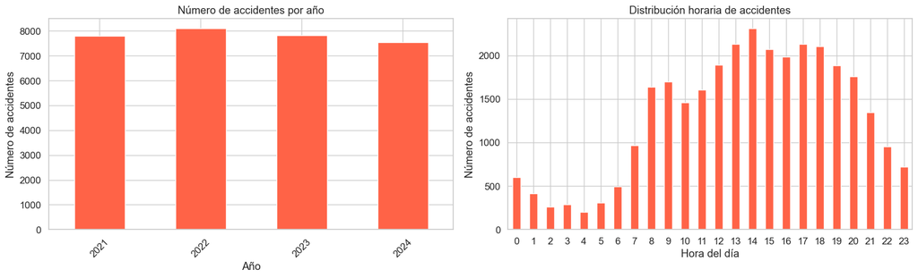

```python
# Accidentes por año y hora
fig, axes = plt.subplots(1, 2, figsize=(16, 5))

# Por año
df_acc['NK_Any'].value_counts().sort_index().plot(
    kind='bar', ax=axes[0], color='tomato', edgecolor='white'
)
axes[0].set_title('Número de accidentes por año')
axes[0].set_xlabel('Año')
axes[0].set_ylabel('Número de accidentes')
axes[0].set_xticklabels(axes[0].get_xticklabels(), rotation=45)

# Por hora del día
df_acc['Hora_dia'].value_counts().sort_index().plot(
    kind='bar', ax=axes[1], color='tomato', edgecolor='white'
)
axes[1].set_title('Distribución horaria de accidentes')
axes[1].set_xlabel('Hora del día')
axes[1].set_ylabel('Número de accidentes')
axes[1].set_xticklabels(axes[1].get_xticklabels(), rotation=0)

plt.tight_layout()
plt.show()
```

### Análisis de la siniestralidad vial

Panel izquierdo: el número de accidentes es muy estable: ~7.800 en 2021, ~8.100 en 2022, ~7.800 en 2023 y ~7.500 en 2024. No hay tendencia clara al alza ni a la baja. La pandemia no dejó huella visible en 2021, posiblemente porque los datos incluyen toda la tipología de accidentes y el año ya era post-restricciones.

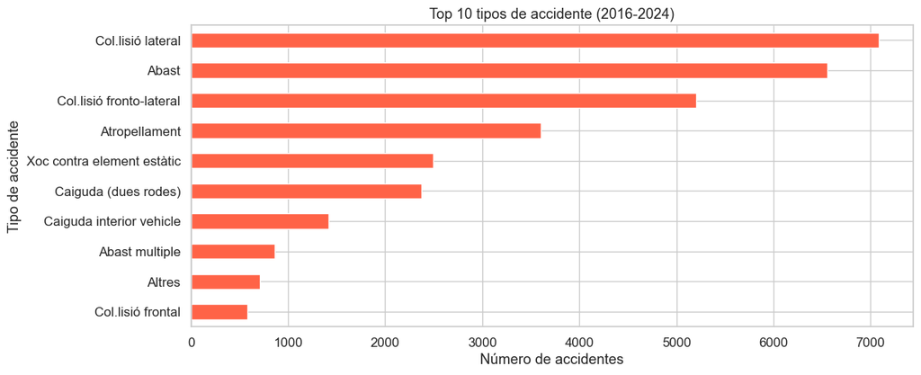

```python
# Top 10 tipos de accidente
top_tipos_acc = df_acc['Descripcio_tipus_accident'].value_counts().head(10)

fig, ax = plt.subplots(figsize=(12, 5))
top_tipos_acc.plot(kind='barh', ax=ax, color='tomato')
ax.set_title('Top 10 tipos de accidente (2016-2024)')
ax.set_xlabel('Número de accidentes')
ax.set_ylabel('Tipo de accidente')
ax.invert_yaxis()
plt.tight_layout()
plt.show()
```

### Tipología de accidentes

La col·lisió lateral (colisión lateral) es el tipo más frecuente con diferencia (~7.100 casos), seguida del abast (alcance, choque por detrás) con ~6.500. La col·lisió fronto-lateral suma ~5.200. Los tres primeros tipos son todos colisiones entre vehículos, lo que sugiere que la mayoría de accidentes ocurren en intersecciones o por distanciamiento insuficiente. El atropellament (atropello) aparece en cuarto lugar con ~3.600 casos, relevante dado el elevado tráfico peatonal de Barcelona.

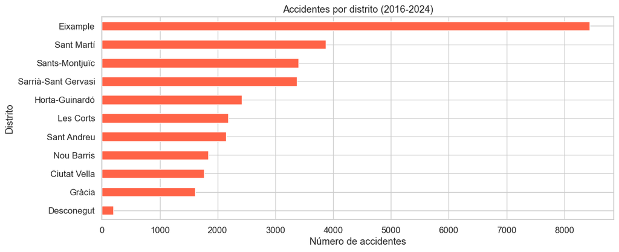

```python
# Accidentes por distrito
acc_distrito = df_acc['Nom_districte'].value_counts()

fig, ax = plt.subplots(figsize=(12, 5))
acc_distrito.plot(kind='barh', ax=ax, color='tomato')
ax.set_title('Accidentes por distrito (2016-2024)')
ax.set_xlabel('Número de accidentes')
ax.set_ylabel('Distrito')
ax.invert_yaxis()
plt.tight_layout()
plt.show()
```

### Distribución por distritos

El Eixample domina con más de 8.000 accidentes — más del doble que el segundo distrito. Esto no sorprende: el Eixample concentra la mayor densidad de intersecciones, tráfico y población de la ciudad. Le siguen Sant Martí (~3.900) y Sants-Montjuïc y Sarrià-Sant Gervasi (ambos ~3.400). Gràcia tiene el número más bajo de todos los distritos identificados (~1.600), a pesar de ser un distrito céntrico, lo que podría deberse a su red de calles estrechas con menor velocidad de circulación.

## 7. Integración inicial: Tráfico × Eventos

Análisis preliminar del impacto de los eventos festivos sobre la intensidad de tráfico.

```python
# Preparar tabla de eventos (festivales con fechas válidas)
df_fiestas = BASE / 'Fiestas'
df_eventos = df_festivales[
    df_festivales['DataInici'].notna() &
    (df_festivales['DataInici'].dt.year >= 2022) &
    (df_festivales['DataInici'].dt.year <= 2024)
].copy()

# Crear conjunto de fechas con evento
fechas_con_evento = set()
for _, row in df_eventos.iterrows():
    fi = row['DataInici']
    ff = row['DataFi'] if pd.notna(row['DataFi']) else fi
    for d in pd.date_range(fi, ff):
        fechas_con_evento.add(d.date())

print(f'Días con al menos un evento (2022-2024): {len(fechas_con_evento)}')
```

```
Días con al menos un evento (2022-2024): 160
```

```python
# Marcar días con/sin evento en los datos de tráfico
df_traf['hay_evento'] = df_traf['fecha'].isin(fechas_con_evento)

print('Registros de tráfico:')
print(df_traf['hay_evento'].value_counts())
```

```
Registros de tráfico:
hay_evento
False    14412350
True      1262196
Name: count, dtype: int64
```

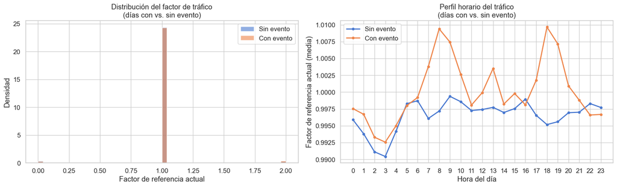

```python
# Comparación del factor de tráfico: días con evento vs. sin evento
fig, axes = plt.subplots(1, 2, figsize=(16, 5))

# Distribución general
for hay_evento, grupo in df_traf.groupby('hay_evento'):
    etiqueta = 'Con evento' if hay_evento else 'Sin evento'
    grupo['factorReferenciaActual'].plot(
        kind='hist', bins=50, ax=axes[0], alpha=0.6, label=etiqueta, density=True
    )
axes[0].set_title('Distribución del factor de tráfico\n(días con vs. sin evento)')
axes[0].set_xlabel('Factor de referencia actual')
axes[0].set_ylabel('Densidad')
axes[0].legend()

# Perfil horario comparado
perfil_evento = df_traf.groupby(['hay_evento', 'hora'])['factorReferenciaActual'].mean().unstack(0)
perfil_evento.columns = ['Sin evento', 'Con evento']
perfil_evento.plot(ax=axes[1], linewidth=2, marker='o', markersize=4)
axes[1].set_title('Perfil horario del tráfico\n(días con vs. sin evento)')
axes[1].set_xlabel('Hora del día')
axes[1].set_ylabel('Factor de referencia actual (media)')
axes[1].set_xticks(range(24))
axes[1].legend()

plt.tight_layout()
plt.show()
```

### Impacto de los eventos en el tráfico

```python
# Test estadístico: ¿existe diferencia significativa en el factor de tráfico?
from scipy import stats

grupo_evento   = df_traf[df_traf['hay_evento']]['factorReferenciaActual'].dropna()
grupo_no_event = df_traf[~df_traf['hay_evento']]['factorReferenciaActual'].dropna()

# Mann-Whitney U (no paramétrico)
stat, p_value = stats.mannwhitneyu(grupo_evento, grupo_no_event, alternative='two-sided')

print(f'Media días con evento:    {grupo_evento.mean():.4f}')
print(f'Media días sin evento:    {grupo_no_event.mean():.4f}')
print(f'Diferencia:               {grupo_evento.mean() - grupo_no_event.mean():.4f}')
print(f'\nTest Mann-Whitney U: stat={stat:.2f}, p-value={p_value:.4e}')
if p_value < 0.05:
    print('→ Diferencia estadísticamente significativa (p < 0.05)')
else:
    print('→ No hay diferencia estadísticamente significativa')
```

```
Media días con evento:    1.0004
Media días sin evento:    0.9967
Diferencia:               0.0037

Test Mann-Whitney U: stat=5639156438251.50, p-value=1.1242e-105
→ Diferencia estadísticamente significativa (p < 0.05)
```